# Tarea 4_Ricardo Zamora Mennigke_Mineria de Datos I

1. Cargue la tabla de datos ZipData 2020.csv en R.

```r
setwd("C:/Users/rzamoram/Documents/Machine Learning/Mineria de Datos I/Clase3")
data2<-read.csv("ZipData_2020.csv",sep=";",dec='.',header=T)
head(data2)
```

```
##   Numero V2 V3 V4     V5     V6     V7     V8     V9    V10    V11    V12
## 1   seis -1 -1 -1 -1.000 -1.000 -1.000 -1.000 -0.631  0.862 -0.167 -1.000
## 2  cinco -1 -1 -1 -0.813 -0.671 -0.809 -0.887 -0.671 -0.853 -1.000 -1.000
## 3 cuatro -1 -1 -1 -1.000 -1.000 -1.000 -1.000 -1.000 -1.000 -0.996  0.147
## 4  siete -1 -1 -1 -1.000 -1.000 -0.273  0.684  0.960  0.450 -0.067 -0.679
## 5   tres -1 -1 -1 -1.000 -1.000 -0.928 -0.204  0.751  0.466  0.234 -0.809
## 6   seis -1 -1 -1 -1.000 -1.000 -0.397  0.983 -0.535 -1.000 -1.000 -1.000
##      V13    V14    V15    V16 V17 V18 V19 V20    V21    V22    V23    V24
## 1 -1.000 -1.000 -1.000 -1.000  -1  -1  -1  -1 -1.000 -1.000 -1.000 -0.992
## 2 -0.774 -0.180  0.052 -0.241  -1  -1  -1  -1  0.392  1.000  0.857  0.727
## 3  1.000 -0.189 -1.000 -1.000  -1  -1  -1  -1 -1.000 -1.000 -1.000 -1.000
## 4 -1.000 -1.000 -1.000 -1.000  -1  -1  -1  -1 -1.000 -0.114  0.974  0.917
## 5 -1.000 -1.000 -1.000 -1.000  -1  -1  -1  -1 -1.000 -0.370  0.739  1.000
## 6 -1.000 -1.000 -1.000 -1.000  -1  -1  -1  -1 -1.000 -1.000  0.692  0.536
##      V25    V26    V27    V28    V29    V30    V31    V32 V33 V34 V35 V36
```

[output cut: 146 more lines]

```r
str(data2)
```

```
## 'data.frame':    9298 obs. of  257 variables:
##  $ Numero: Factor w/ 10 levels "cero","cinco",..: 7 2 3 8 9 7 9 10 1 10 ...
##  $ V2    : num  -1 -1 -1 -1 -1 -1 -1 -1 -1 -1 ...
##  $ V3    : num  -1 -1 -1 -1 -1 -1 -1 -1 -1 -1 ...
##  $ V4    : num  -1 -1 -1 -1 -1 -1 -1 -1 -1 -1 ...
##  $ V5    : num  -1 -0.813 -1 -1 -1 -1 -0.83 -1 -1 -1 ...
##  $ V6    : num  -1 -0.671 -1 -1 -1 -1 0.442 -1 -1 -1 ...
##  $ V7    : num  -1 -0.809 -1 -0.273 -0.928 -0.397 1 -1 -0.454 -1 ...
##  $ V8    : num  -1 -0.887 -1 0.684 -0.204 0.983 1 -1 0.879 -1 ...
##  $ V9    : num  -0.631 -0.671 -1 0.96 0.751 -0.535 0.479 0.51 -0.745 -0.909 ...
##  $ V10   : num  0.862 -0.853 -1 0.45 0.466 -1 -0.328 -0.213 -1 0.801 ...
##  $ V11   : num  -0.167 -1 -0.996 -0.067 0.234 -1 -0.947 -1 -1 -0.899 ...
##  $ V12   : num  -1 -1 0.147 -0.679 -0.809 -1 -1 -1 -1 -1 ...
##  $ V13   : num  -1 -0.774 1 -1 -1 -1 -1 -1 -1 -1 ...
##  $ V14   : num  -1 -0.18 -0.189 -1 -1 -1 -1 -1 -1 -1 ...
```

[output cut: 86 more lines]

2. Use el m´etodo de Arboles de Decisi´on con el m´etodo y los par´ametros que usted conside- ´re m´as conveniente para generar un modelo predictivo para la tabla ZipData 2020.csv usando el 80 % de los datos para la tabla aprendizaje y un 20 % para la tabla testing, luego calcule para los datos de testing la matriz de confusi´on, la precisi´on global y la precisi´on para cada una de las categor´ıas. ¿Son buenos los resultados? Explique.

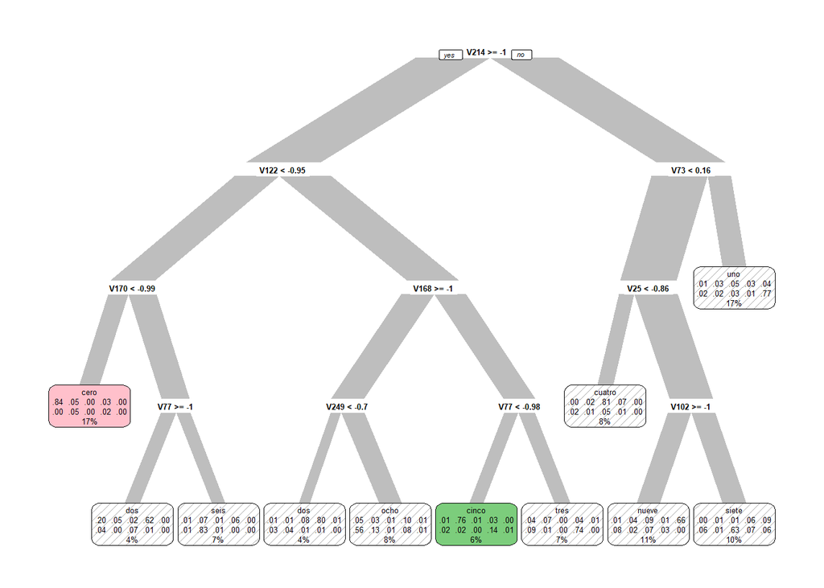

```r
muestra <- sample(1:nrow(data2),floor(nrow(data2)*0.20))
ttesting <- data2[muestra,]
taprendizaje <- data2[-muestra,]
modelo <- train.rpart(formula = Numero~.,
               data = taprendizaje,
               minsplit = 2)
prediccion <- predict(modelo,
                      ttesting,
                      type='class')
prp(modelo,
    extra = 104,
    branch.type = 2,
    box.col=c("pink", "palegreen3")[modelo$frame$yval])
```

```r
MC <- confusion.matrix(ttesting, prediccion)
indices.general(MC)
```

```
## $`Matriz de Confusión`
##         prediction
## real     cero cinco cuatro dos nueve ocho seis siete tres uno
##   cero    280     0      1  17     1    8    0     1    5   2
##   cinco    13    70      0   3     6    6    7     0   18   4
##   cuatro    0     1    115   8    18    3    1     0    0  15
##   dos       9     3      9 108     2   21   11    13    9   9
##   nueve     0     0      2   0   121    2    0    19    1  17
##   ocho      0     3      2   6    12   82    2    15   12   3
##   seis     15     4      2   3     3   30   99     0    0   4
##   siete     1     0      4   7    20    1    0   108    0  12
##   tres     17    25      2   4     6   12    0    16  119   0
##   uno       0     0      2   2     0    3    0    17    0 225
##
## $`Precisión Global`
## [1] 0.7138246
##
## $`Error Global`
## [1] 0.2861754
##
## $`Precisión por categoría`
##      cero     cinco    cuatro       dos     nueve      ocho      seis     siete
## 0.8888889 0.5511811 0.7142857 0.5567010 0.7469136 0.5985401 0.6187500 0.7058824
##      tres       uno
## 0.5920398 0.9036145
##
## $`Precision Positiva`
## [1] 0.8433735
##
## $`Precision Negativa`
## [1] 1
##
## $`Falsos Positivos`
## [1] 0
##
## $`Falsos Negativos`
## [1] 0.1566265
##
## $`Asertividad Positiva`
## [1] 1
##
## $`Asertividad Negativa`
## [1] 0.9556314
```

3. Compare los resultados con los obtenidos en las tareas anteriores.

Debe senalarse que de los modelos anteriores el de arboles de decision tiene peor desempeno. A pesar de ello, puede senalarse la red neuronal tanto nnet como neuralnet tardan mucho en procesar los datos, mucho mas que en el caso de los kvecinos, por lo que, para el uso de equipo con baja capacidad de procesamiento puede resultar mas optimo kvencinos. En el caso de los kvecinos se obtuvieron mejores resultados. La precision global de 0.9585799, con kvecinos es superior que con la aproximacion de redes nnet (0.8682087).